# Analysing muscle oxidative capacity with mnirs

Author

Jem I Arnold

Published

September 11, 2026

# Introduction

The [`{mnirs}`](https://github.com/jemarnold/mnirs) package is under active development with processing and analysis methods for muscle near-infrared spectroscopy in R.

This article demonstrates recently added functionality in *{mnirs}* can be combined to perform muscle oxidative capacity (OxCap) analysis from a repeated ischaemic occlusion protocol, ensuring reproducibility and adhering to current gold-standard processing methods.

**Note**

This article assumes basic familiarity with the *{mnirs}* package. For an overview and demonstration of data processing with *{mnirs}*, please see the original package vignette [*Reading and Cleaning Data with mnirs*](https://jemarnold.github.io/mnirs/articles/reading-mnirs-data.html).

**Tip**

Skip to the analysis code below if you are already familiar with the method.

## Muscle oxidative capacity testing

One of the most compelling applications emerging in mNIRS research is the non-invasive evaluation of gross **muscle oxidative capacity** after a dynamic exercise task.

Oxidative capacity is the maximal rate at which a muscle utilises oxygen (O<sub>2</sub>) to meet the energetic demand of exercise, and is related to mitochondrial respiratory function (Beever et al., 2020).

Traditional mitochondrial oxidative capacity assessment requires invasive in-vitro methods such as high-resolution respirometry of biopsy tissue, or expensive in-vivo <sup>31</sup>P magnetic resonance spectroscopy. mNIRS is comparatively far more accessible, and allows non-invasive assessment during dynamic exercise tasks, at lower cost and with lower participant burden.

## Protocol overview

The participant performs a brief exercise task or muscle stimulation to elevate O<sub>2</sub> extraction (mV̇O<sub>2</sub>) demand in the target tissue, with mNIRS sensors over the muscle of interest and an occlusion cuff around the proximal limb.

Immediately after the stimulus, the cuff is rapidly inflated to a supra-systolic pressure (e.g. 300 mmHg), transiently stopping blood flow into the distal target muscle. The occlusion is held briefly (e.g. 5 s) then rapidly deflated to allow recovery. A sequence of these brief, repeated occlusions are performed at a pre-specified tempo (e.g. 5-sec occlusion, 10-sec recovery) for up to twenty repetitions (~5 min), until the muscle recovers to baseline.

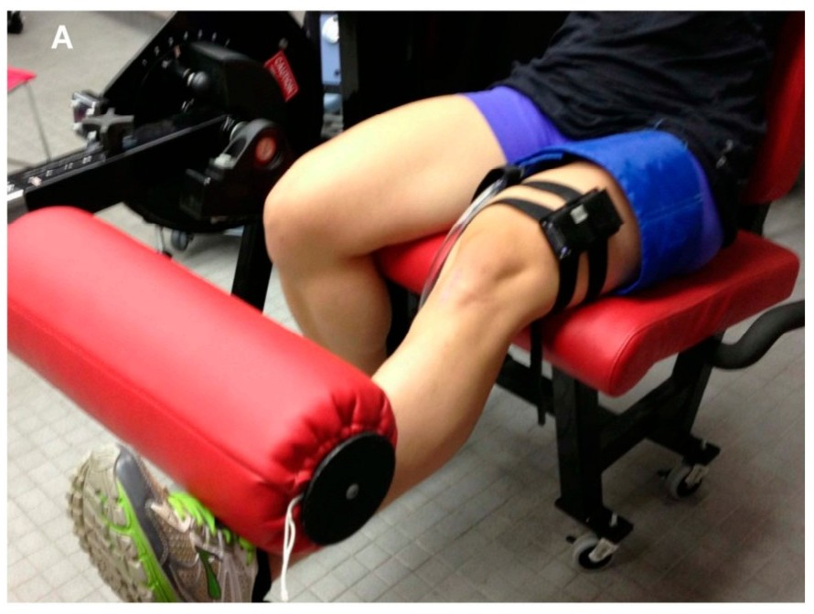

Figure 2 from McCully et al. (2024). (A) The experimental setup for the progressive exercise test. The NIRS device was placed on the vastus lateralis using straps. The blood pressure cuff was placed proximal to the NIRS device. The leg is shown lifting the weight. For NIRS measurements, the leg was placed on top of the padding in the horizontal position to allow the muscle to relax during the measurements.

During each occlusion, oxygen delivery is restricted and assumed to be zero. The rate of deoxygenation — the slope of the rise in deoxy[haem] (HHb/time; μM/sec), or decline in oxygen saturation (SmO<sub>2</sub>) or oxy[haem] — is therefore interpreted as the rate of local muscle oxygen uptake (mV̇O<sub>2</sub>).

mV̇O<sub>2</sub> is elevated immediately after the exercise task, then recovers exponentially toward baseline. The rate constant (*k*, min<sup>-1</sup>) of this monoexponential curve quantifies the muscle OxCap value (Adami & Rossiter, 2018).

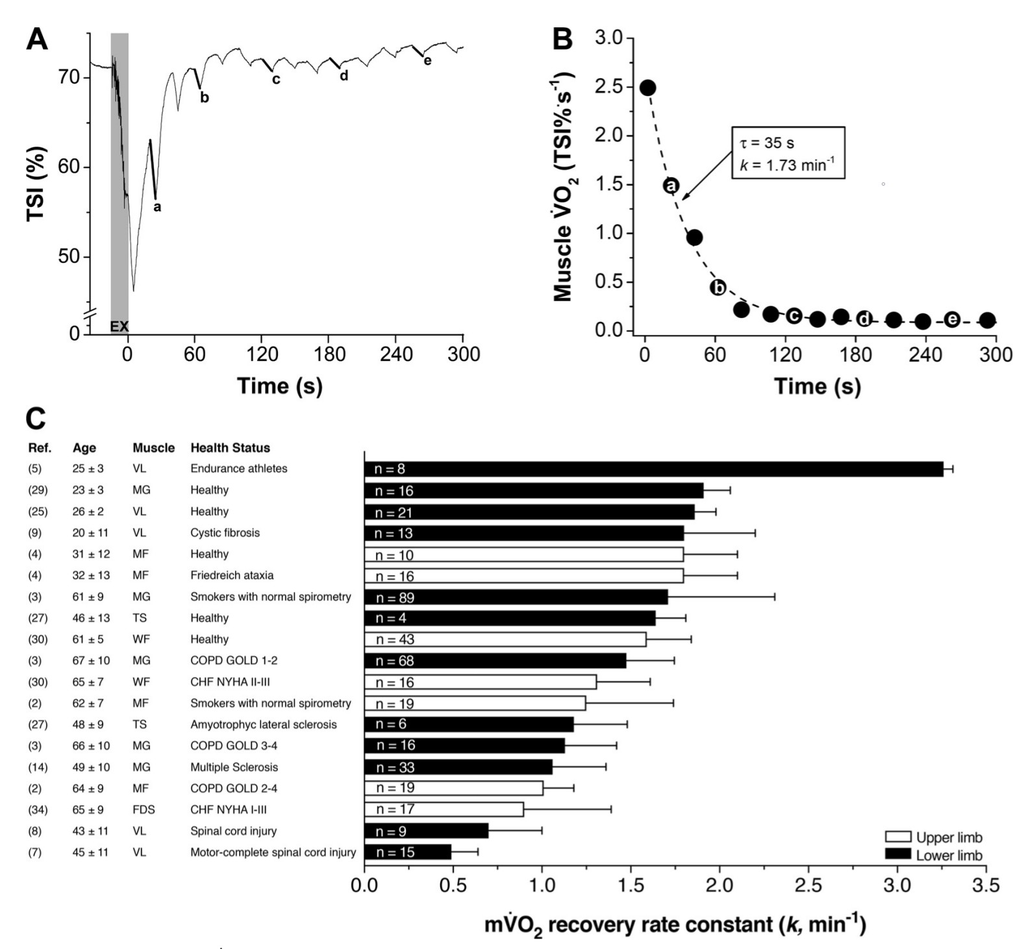

Figure 1 from Adami & Rossiter (2018). Muscle oxygen consumption (mVO2) recovery rate constant (k) by near-infrared spectroscopy. A and B: example of the oxidative capacity test by NIRS. A: changes in the tissue saturation index (TSI) during dynamic exercise (EX, gray area) and subsequent intermittent arterial occlusions at rest. B: mVO2 recovery kinetics derived from the rate of change of TSI during intermittent arterial occlusions measured from A. mVO2 recovery data are fit to an exponential (dashed line) to estimate the recovery k. C: summaries of current reports of the mVO2 recovery rate constant (k), which is proportional to oxidative capacity, in upper and lower limbs of adults in health and disease.

This technique is well validated against <sup>31</sup>P-MRS (Ryan et al., 2013) and mitochondrial content protein markers (Tripp et al., 2023). The rate constant *k* is proportionally higher (faster recovery) in endurance-trained muscle, and lower (slower) in untrained, older, or diseased muscle (Adami & Rossiter, 2018).

## A call for standardised processing methods

Technical and analysis methods for OxCap assessment have converged toward standardisation in recent years, with good demonstrated reliability and reproducibility. There has been a recent call to implement standard analysis scripts with robust slope detection and non-linear modelling, to minimise operator-related variability between research centres, and improve interpretation of outcomes across populations and interventions (Costalat et al., 2025; Rasica et al., 2024).

This article uses recently developed *{mnirs}* functionality to process and analyse repeated occlusion muscle OxCap data. In the future, this could be wrapped into a single convenience function, but the current process is already considerably simpler and more robust than methods relying on manual data cleaning, manual interval selection, and iterative (e.g. Excel macro) curve fitting.

## Analysis plan

For OxCap analysis, we will perform roughly 8 steps:

1. Import an example mNIRS file with the repeated occlusions procedure.
2. Process/clean data, as needed (minimal in this example).
3. Iteratively correct NIRS values for changes in blood volume, a required step to ensure valid analysis.
4. Specify occlusion events in the data and extract a 5-sec interval for each occlusion.
5. Find the peak 3-sec linear regression NIRS slope within each occlusion interval.
6. Fit a monoexponential curve across NIRS slope observations for both repeated occlusion trials.
7. Extract the rate constant (*k*) for each trial exponential curve.
8. Plot the modelled data.

# Oxidative capacity analysis with *{mnirs}*

This article serves as a vignette for some of the kinetics analysis functions recently added to *{mnirs}*, and how they combine to perform robust OxCap analysis.

- `correct_blood_volume()` normalises values for oxy[haem], deoxy[haem], and total[haem] channels (if present), using an iterative method developed from Beever et al. (2020) that properly accommodates negative values. See `?correct_blood_volume` for details.
- `extract_intervals()` detects specific events or times in an *“mnirs”* data frame, extracts an interval around each one, and returns a list of data frames. The returned list of data frames is ready for further analysis. See `?extract_intervals` for details.
- `analyse_kinetics()` evaluates mNIRS response kinetics from a single *“mnirs”* data frame or a list of data frames, with a selection of parametric and non-parametric methods. It returns a formatted table of model results, with internal model components retrieved with `results$...`. See `?analyse_kinetics` for details.  
  We will use this function twice for OxCap analysis:
  - `analyse_kinetics(method = "peak_slope")` finds the peak linear regression slopes on deoxy[haem] from the extracted occlusion intervals. The steepest (positive or negative) slope is often interpreted as the point of greatest mismatch between O<sub>2</sub> supply and extraction. See `?peak_slope` for details on the vector-level function called by `analyse_kinetics()`.
  - `analyse_kinetics(method = "monoexponential")` then fits an exponential curve through the resulting slope values over time, to find the rate constant *k*. A self-starting function `SSmonoexponential()` is fit with `stats::nls()`, called as either a **4-parameter** model with a time-delay parameter (*TD*), or a reduced **3-parameter** model without *TD* where response onset is expected to be immediate. See `?monoexponential` and `?SSmonoexponential` for details.

## Setup

First, load our packages and initial setup options.

```r
library(dplyr)   ## for convenient data wrangling
library(ggplot2) ## for plotting
library(mnirs)   ## install: pak::pak("jemarnold/mnirs@dev")

options(mnirs.verbose = FALSE) ## silence mnirs messages
```

**NoteAcknowledgement**

I received this example file from [Dr. Thomas Tripp](https://scholar.google.com/citations?user=A9JwQbYAAAAJ&hl=en), currently a postdoctoral fellow in [Dr. Martin MacInnis](https://scholar.google.com/citations?hl=en&user=tJepNIQAAAAJ)’ lab at the University of Calgary. They have kindly allowed me to include this file with the *{mnirs}* package for users to examine themselves.

It can be accessed by calling `example_mnirs("portamon_oxcap")`.

# Read *{mnirs}* data file

The included example file has three NIRS channels and a sample-number column, automatically converted to a time value by `read_mnirs()`. The file needs no other pre-processing steps.

Note: by default, *Artinis Oxysoft* exports an event label column without a named header. `read_mnirs()` renames this to *“labels”*. This is the column we will use to identify occlusion events by the label *“Occlusion”*.

```r
## identify and rename channels, including the event label column
df <- read_mnirs(
    file_path     = example_mnirs("portamon_oxcap.xlsx"),
    nirs_channels = c(thb = 2, hhb = 3, o2hb = 4),
    event_channel = c(event = "labels")
)

## view the structure of our data frame
df
```

```
#> # A tibble: 7,944 × 6
#>     time sample event   thb   hhb  o2hb
#>    <dbl>  <dbl> <chr> <dbl> <dbl> <dbl>
#>  1   0        0 <NA>   146.  63.0  82.9
#>  2   0.1      1 <NA>   146.  63.0  82.8
#>  3   0.2      2 <NA>   146.  63.0  82.8
#>  4   0.3      3 <NA>   146.  63.0  82.9
#>  5   0.4      4 <NA>   146.  63.0  82.7
#>  6   0.5      5 <NA>   146.  62.9  82.6
#>  7   0.6      6 <NA>   146.  62.9  82.7
#>  8   0.7      7 <NA>   146.  62.9  82.8
#>  9   0.8      8 <NA>   146.  62.9  82.7
#> 10   0.9      9 <NA>   146.  62.9  82.7
#> # ℹ 7,934 more rows
```

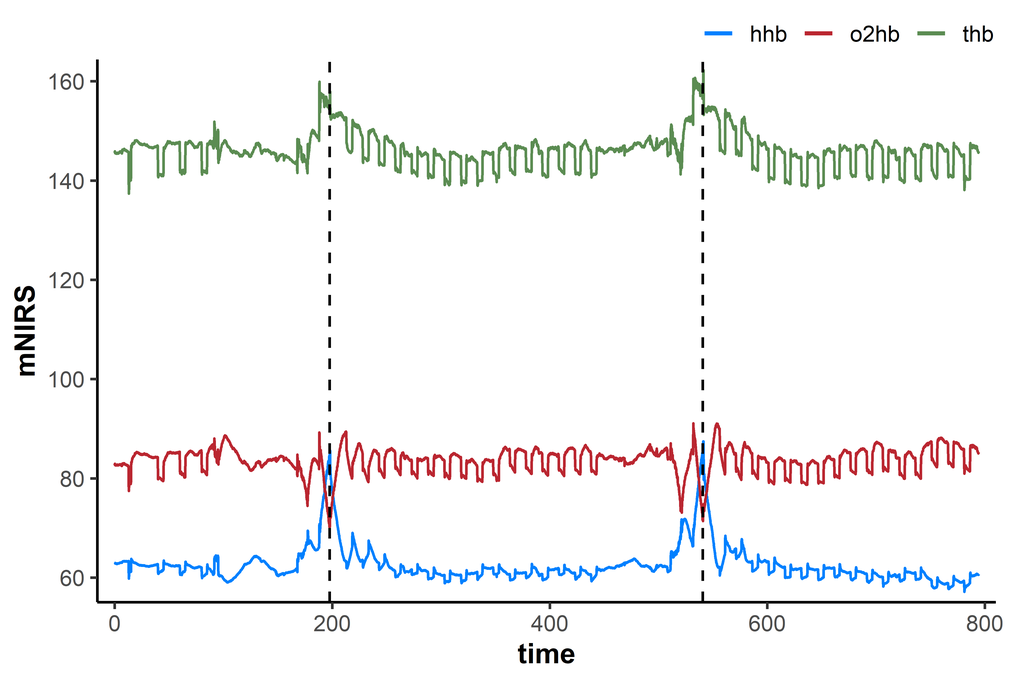

```r
## plot the two trial start events
trial_times <- df$time[grepl("Trial Start", df$event)]

plot(df, label_time = TRUE) +
    geom_vline(xintercept = trial_times, linetype = "dashed")
```

The two repeated occlusion trials are clearly identifiable from the raw data plot. A few resting occlusions were also performed at the start of the file, which we will ignore for now.

# Correct for blood volume

Before analysing the OxCap trials, the NIRS channels must be corrected for changes in blood volume during the repeated occlusions. This ensures validity when evaluating NIRS slopes (Ryan et al., 2012).

The preferred method proposed by Beever et al. (2020) iteratively corrects for instantaneous changes in oxygenation between samples. `correct_blood_volume()` implements this method, further developed to accommodate negative NIRS values, which can be reported by some mNIRS devices.

## `correct_blood_volume()`

- `data`

  This function takes a data frame (or a list of data frames), corrects the specified NIRS channels for changes in blood volume (*Δtotal[haem]*), and returns the data frame with the corrected `nirs_channels`.  
  These channels cannot be read automatically from *“mnirs”* metadata, to avoid ambiguity. The corrected channels are passed on in metadata as `nirs_channels` for further analysis.

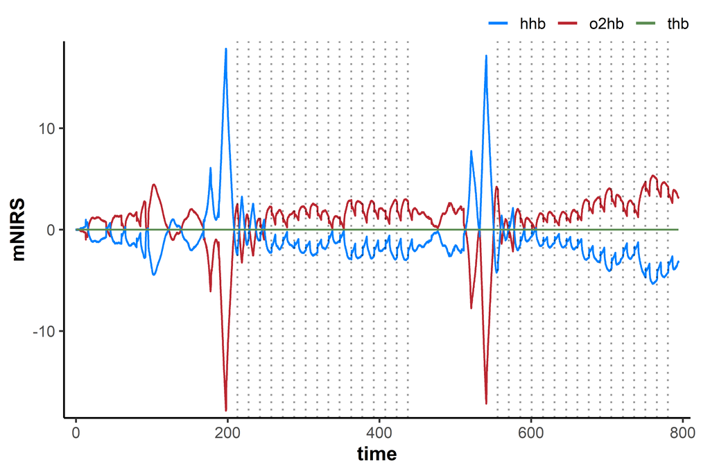

```r
df <- df |>
    correct_blood_volume(
        oxy_channel   = o2hb,
        deoxy_channel = hhb,
        total_channel = thb
    )

## plot corrected data with occlusion event indicators
occl_times <- df$time[grepl("Occlusion", df$event)]

plot(df, label_time = TRUE) +
    geom_vline(xintercept = occl_times, linetype = "dotted", alpha = 0.4)
```

This correction results in a symmetrical distribution of oxy- and deoxy[haem], with the sum total (total[haem]; THb) definitionally equal to zero at all samples.

Occlusions from the labels in `event_channel` are also plotted (vertical dotted lines) to visually confirm timing and detect any erroneous events.

# Extract occlusion intervals

The next step is to detect and extract each interval around these occlusion event labels into a data frame for iterative kinetics analysis. We will also need to split the analysis into the two discrete trials.

## `extract_intervals()`

- `data`

  This function takes a data frame or list of data frames, and returns a list of data frames, named per detected interval. *“mnirs”* metadata is passed to and from this function.
- `nirs_channels`, `time_channel`, `event_channel`, & `sample_rate`

  Specify which column names in `data` will be processed. `nirs_channels` are the response variables; `time_channel` is the predictor variable; `event_channel` specifies where to look for events as either character labels or integer laps; and `sample_rate` carries the exported samples-per-second rate used when ensemble-averaging across intervals. Arguments left unspecified are retrieved from *“mnirs”* metadata by default.  
  We will analyse OxCap from the deoxy[haem] (*“HHb”*) NIRS signal, as recommended (Costalat et al., 2025).
- `start` & `end`

  Interval boundaries are specified using helper functions: `by_time()` for `time_channel` values; `by_label()` for `event_channel` labels; `by_lap()` for lap indices in `event_channel`; or `by_sample()` for sample indices (row numbers). Provide both `start` and `end` to define precise intervals, or `start` alone with `span` to extract a window around events (see below).  
  Since the occlusions are all identified by the event label *“Occlusion”*, we can look for this string as the `start` value to extract each interval.  
  Event labels are matched as regular expressions (regex) by default, so a partial string will match. Use `fixed = TRUE` for literal matching, or `ignore_case = TRUE` to match case-insensitively.
- `group_intervals`

  Multiple events can be extracted for analysis as *“distinct”* intervals, or *“ensemble”*-averaged together. Different groupings can be ensemble-averaged by providing a list of intervals by number, e.g. `list(c(1, 2), c(3, 4))`.  
  For manual grouping, interval numbers must be known ahead of time and always refer to order of occurrence in the data frame (sorted by `time_channel`). For this example, we analyse each interval separately using the default `group_intervals = "distinct"`.
- `span`

  A two-element vector of `time_channel` values specifying a time window `c(start, end)` in units of `time_channel`, where positive values indicate time after the event bound and negative values indicate time before. `span[1]` shifts the start bound, `span[2]` shifts the end bound, respectively.  
  Since all occlusion bouts were held for 5 s, we use a 5-sec time span. If occlusion duration changed through the protocol, we could specify a list of time spans (`span = list()`); here a single vector is recycled.  
  Visual inspection (not shown) revealed that the deoxy[haem] signal was disrupted by cuff inflation during the first 0.5-1.0 sec of each occlusion interval, which might influence slope values. We therefore exclude the first second with `span = c(1, 5)`, i.e. extract from 1-sec to 5-sec after each *“Occlusion”* label.
- `zero_time`

  Time values for each event interval can be recalculated to start from zero at the event indicator. Ensemble-averaged intervals are always rebased to zero, since original time values are obsolete when ensembling.  
  For repeated occlusion testing, the original time information per interval is needed to subsequently model the exponential recovery function, so we keep `zero_time = FALSE`.

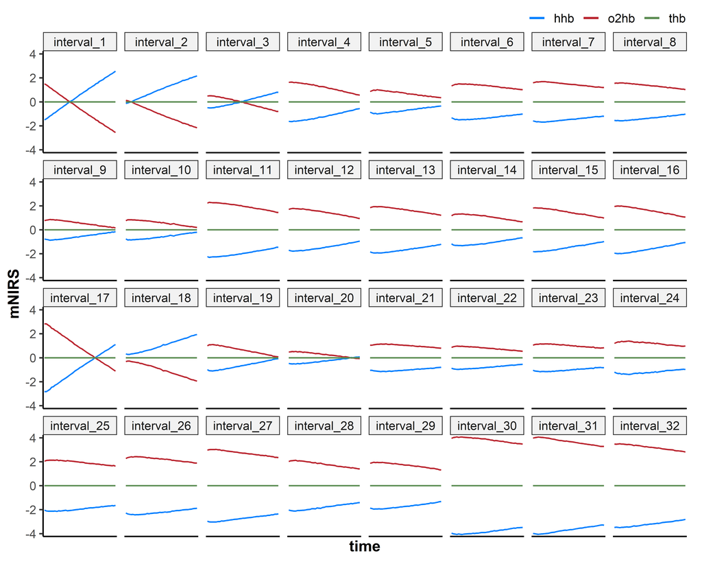

```r
## extract all occlusion events from the data at once
## we can specify the two-trial structure later
## extract intervals in a 1-5 sec span after each event
df_list <- extract_intervals(
        df,
        group_intervals = "distinct",
        start           = by_label("Occlusion"),
        span            = c(1, 5), ## span in reference to `start` times
        zero_time       = FALSE    ## preserve original time values
    )

## visualise all occlusion intervals for error checking
## expecting 2 x 16 = 32 total
plot(df_list, ncol = 8) +
    theme(axis.text.x = element_blank(), axis.ticks.x = element_blank())
```

Next, we calculate the slope value for each occlusion interval.

# Calculate occlusion slopes

## `analyse_kinetics()`

- `data`

  This function takes a data frame or list of data frames, analyses all channels separately, and returns a single formatted table of results. Model components such as coefficients, fitted data frames, intake metadata, and diagnostics can be retrieved from results metadata with `results$...`.
- `nirs_channels` & `time_channel`

  If the data contain *“mnirs”* metadata, these are detected automatically; otherwise they can be specified explicitly.
- `start_time`, `direction`, & `end_window`

  These arguments apply to every method. `start_time` marks the response onset. When intervals come from `extract_intervals()`, it is retrieved automatically from *“mnirs”* metadata. Otherwise it defaults to the first non-negative time value (i.e. `0`).  
  `direction` detects whether the response rises (*“positive”*) or falls (*“negative”*), and defaults to *“auto”*. For parametric fits it also constrains the expected response direction, in case of ambiguous kinetics. For deoxy[haem], we specify `direction = "positive"`, since deoxygenation increases during occlusions.  
  `end_window` defines the end of the fitting window by looking forward for a reasonable end time, taking the first peak or trough (for rising or falling response, respectively) with no more extreme value within that span. The default `end_window = Inf` uses the global extreme across the whole interval, appropriate for these short occlusion windows.
- `method`

  Multiple analysis methods are currently available. This OxCap analysis uses *“peak_slope”* and *“monoexponential”*, then *“exponential_drift”* as an exploratory extension below.

### Analyse peak slope kinetics

- `method = "peak_slope"`

The **peak slope** method is a *semi-parametric* approach: it fits a linear regression model across a rolling local window, returning the single steepest slope along with the time at which it occurs. For OxCap analysis, the steepest local rate of deoxygenation is interpreted as the point of greatest mismatch between O<sub>2</sub> delivery and extraction — a proxy for mV̇O<sub>2</sub> during each occlusion.

- `width`, `span`

  The local window is specified by either `width` (a number of samples) or `span` (a range of time in units of `time_channel`). Here we want the peak slope from a 3-sec span within each occlusion interval.
- `align`

  The window can be *“centre”*-aligned around the target sample (`idx`), *“left”*-aligned with `idx` at the start (forward-looking), or *“right”*-aligned with `idx` at the end (backward-looking). We keep the default `align = "centre"`.
- `partial`

  By default, a local window only returns a linear regression model if all samples within it are valid. If `partial = TRUE`, windows return a slope model as long as two or more samples are available.  
  Windows with fewer samples tend to return steeper slopes, which may not be relevant to our interpretation — e.g. at the edges of a noisy dataset, two samples alone can produce an extreme local slope that we would usually want to ignore.

```r
## find peak 3-sec hhb slopes within each occlusion interval
slope_results <- analyse_kinetics(
    df_list,
    nirs_channels = hhb,
    time_channel  = time,
    method        = "peak_slope",
    span          = 3,
    direction     = "positive",
    partial       = FALSE,
)

## view the formatted results
slope_results
```

```
#>
#> Peak Linear Response Rate
#>     Model Coefficients:
#>             interval nirs_channels start_time  slope intercept peak_slope_time
#>      1:   interval_1           hhb      213.7  1.044    -1.505             1.2
#>      2:   interval_2           hhb      228.5 0.6122   -0.1580             1.2
#>      3:   interval_3           hhb      243.4 0.3869   -0.7273             2.8
#>      4:   interval_4           hhb      258.4 0.3275    -1.877             2.8
#>      5:   interval_5           hhb      273.6 0.1902    -1.094             2.8
#>     --- 22 rows omitted
#>     28:  interval_28           hhb      722.0 0.2043    -2.208             2.1
#>     29:  interval_29           hhb      736.7 0.1902    -2.110             2.8
#>     30:  interval_30           hhb      751.5 0.1968    -4.253             2.8
#>     31:  interval_31           hhb      766.7 0.2230    -4.138             1.8
#>     32:  interval_32           hhb      781.3 0.1925    -3.602             2.7
```

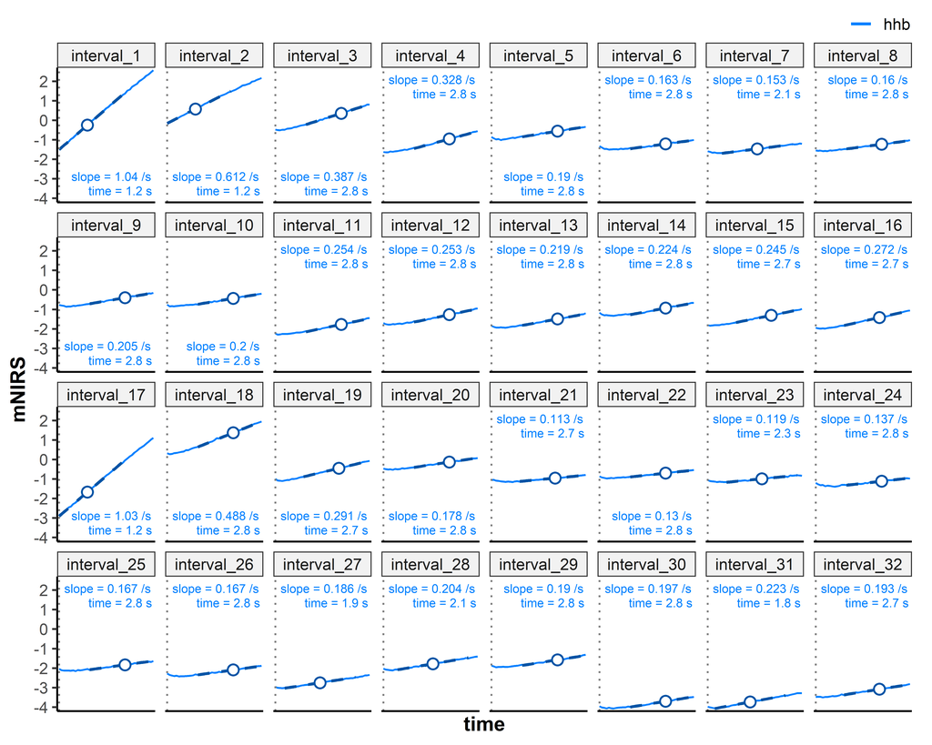

```r
plot(slope_results, ncol = 8, label_size = 3) +
    theme(axis.text.x = element_blank(), axis.ticks.x = element_blank())
```

**Tip**

Individual kinetics results can be quickly visualised with the built-in `plot()` function with coefficient labels (see `?plot.mnirs_kinetics`).

Next, we can recursively analyse the resulting slope coefficients with another `analyse_kinetics()` call using a *“monoexponential”* model to estimate mV̇O<sub>2</sub> recovery.

# Model mV̇O<sub>2</sub> recovery

## `analyse_kinetics()`

### Analyse monoexponential kinetics

- `method = "monoexponential"`

The **monoexponential** method is a *parametric* approach: it fits a self-starting exponential curve to time series data with `stats::nls()`, using `SSmonoexponential()` to initialise starting values. This models how mV̇O<sub>2</sub> recovers back to baseline after the exercise stimulus, and its rate constant *k* is the OxCap outcome.

It fits either a **4-parameter** model `A + (B − A)(1 − exp(−(t − TD) / tau))` with a time delay *TD*, or a reduced **3-parameter** model without *TD* when the response is expected to start immediately.

- `use_TD` (*TD* coefficient)

  An argument used with the exponential methods: it explicitly specifies a **4-parameter** model with a time delay between the stimulus (e.g. at `t = 0`) and the start of a systematic exponential response. The model falls back to a **3-parameter** fit if the 4-parameter fit fails to converge.  
  During repeated occlusions after exercise, the first occlusions may not conform to an exponential response, i.e. if oxygen saturation is too low and limiting to mV̇O<sub>2</sub>. A time delay parameter can capture the true monoexponential response in these cases. This protocol was designed to avoid that delay, so *TD* is not required here.
- *A*, *B* coefficients

  The starting (baseline) and ending (asymptote) values of the monoexponential curve, defining either exponential association (positive direction, *B* > *A*) or decay (negative direction, *A* > *B*).
- *tau*, *k* coefficients

  The time constant (*tau*; τ) describes the time (speed) of the exponential response from *A* to *B*, approximated by the time elapsed at 63.2% of the total response amplitude — i.e. when predicted `y` equals `A + 0.632 × (B − A)`.  
  The rate constant (*k*) is the inverse of the time constant (`k = 1 / tau`) and is also commonly used in NIRS research. *k* is returned as the inverse of `time_channel` units (seconds) by default; here we convert *k* to min<sup>-1</sup>.
- `group_intervals` & `zero_time`

  Note these arguments differ slightly in intent from their `extract_intervals()` counterparts above. Here, `group_intervals` takes a list of **sample (row) numbers**, processing each as separate intervals and returning named groups as interval names. The default *“ensemble”* fits all samples of each data frame together, as in the above `method = "peak_slope"` example.  
  Our `slope_results` has one sample per occlusion, so `list(trial1 = 1:16, trial2 = 17:32)` separates the two trials. As with `extract_intervals()` above, `zero_time` is used to rebase each trial to start from `0`.

```r
## use 3-param monoexponential model without TD
## fit samples in sequence grouped by trial
## channels must be specified explicitly
monoexp_results <- analyse_kinetics(
    slope_results,
    nirs_channels   = slope,  ## supply predictor & response channels
    time_channel    = peak_slope_time,
    method          = "monoexponential",
    use_TD          = FALSE,
    group_intervals = list(trial1 = 1:16, trial2 = 17:32),
    zero_time       = TRUE    ## rebase each trial start_time to zero
)

## view the formatted results
monoexp_results
```

```
#>
#> Monoexponential One-Phase Kinetics
#>     Model Coefficients:
#>   interval nirs_channels     A      B TD   tau       k   MRT
#> 1   trial1     hhb_slope 1.051 0.2104 NA 19.33 0.05174 19.33
#> 2   trial2     hhb_slope 1.034 0.1666 NA 15.39 0.06496 15.39
```

The default plot of *“mnirs_kinetics”* data only reports `tau` (and `TD` & `MRT` if relevant). We want to know both `tau` and `k` in min<sup>-1</sup>, so we will replace the default with a custom label for our results plot.

```r
## extract tau and k coef labels per trial, for plotting
coef_labels <- monoexp_results$coefficients |>
    summarise(
        .by = interval,
        label = sprintf(
            "Trial %s\ntau = %s sec\nk = %s min⁻¹",
            gsub("trial", "", interval),
            round(tau, 1),
            round(k * 60, 1) ## convert to min^-1
        )
    )
```

We can plot our results with some built-in customisation arguments, and additional components built from `{ggplot2}`.

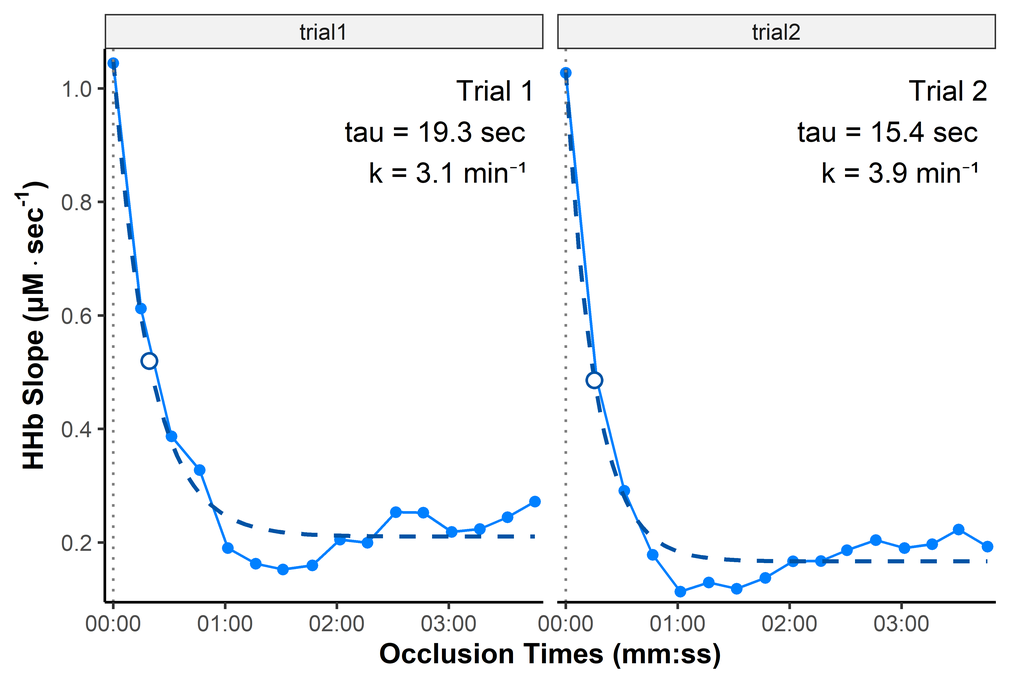

```r
## add custom info to the plot
plot(monoexp_results, time_labels = TRUE, points = TRUE, labels = FALSE) +
    labs(
        x = "Occlusion Times (mm:ss)",
        y = expression(bold(HHb ~ Slope ~ '(' * μM %.% sec^'-1' * ')')),
    ) +
    theme(legend.position = "none") +
    geom_text(
        data = coef_labels, aes(label = label),
        x = Inf, y = Inf, size = 5, hjust = 1.1, vjust = 1.3
    )
```

As a final validation step, we can examine the fitting diagnostics for the two trials.

# Examine fit diagnostics

```r
## call diagnostics and format sigfigs
monoexp_results$diagnostics |>
    mutate(across(where(is.numeric), \(x) signif(x, 3)))
```

```
#>   interval nirs_channels n_obs n_params    r2 adj_r2   rmse cv_rmse  snr   aic
#> 1   trial1     hhb_slope    16        3 0.967  0.962 0.0397   0.130 14.9 -49.8
#> 2   trial2     hhb_slope    16        3 0.975  0.971 0.0343   0.137 16.1 -54.5
#>    aicc   bic
#> 1 -46.2 -46.7
#> 2 -50.8 -51.4
```

The diagnostics are already strong, suggesting valid monoexponential fit. However, we might wonder whether the upward drift in slope values rather than a flat asymptote is physiologically meaningful.

For that, we could use an exploratory third `analyse_kinetics()` method:

## `analyse_kinetics()`

### Analyse exponential-drift kinetics

- `method = "exponential_drift"`

The **exponential-drift** method is a *parametric* two-phase approach: it fits a monoexponential primary response with a secondary linear drift beginning near the primary asymptote, with `stats::nls()` and `SSexponential_drift()`. *A*, *B*, *tau*, and the derived *k*, *MRT*, and *HRT* are interpreted the same as for *“monoexponential”* above. The additional *slope* coefficient is the linear drift rate (in response units per unit `time_channel`).

A slow drift in mV̇O<sub>2</sub> after the primary recovery is physiologically plausible, e.g. from post-occlusion reactive hyperaemia or a slow-component shift in resting metabolic demand. Separating it from the primary response means the exponential phase is no longer forced to absorb the drift into its asymptote. See `?exponential_drift` and `?SSexponential_drift` for details.

- `drift_fraction` (determines where the drift begins)

  The drift onset occurs where the primary response reaches the specified fraction of its amplitude, `TD − tau × log(1 − drift_fraction)`. Before the onset, the drift term is considered to be zero. The reported excursion point *texc* is where the secondary drift rate overtakes the decaying primary rate (the turning point of the curve when the two phases oppose).  
  The default `drift_fraction = 0.95` places drift onset at 95% of the primary amplitude (3 × *tau* after *TD*), i.e. where the primary response is effectively complete. It can be manually adjusted, but smaller fractions allow the drift response to encroach on and absorb more of the primary response, biasing the more physiologically relevant *tau* estimate. We will leave it at the default.

**Caution**

Please note! **Exponential-drift** kinetics is currently experimental based on empirical observation, and remains to be more rigorously validated.

```r
exp_drift_results <- analyse_kinetics(
    slope_results,
    nirs_channels   = slope,
    time_channel    = peak_slope_time,
    method          = "exponential_drift",
    use_TD          = FALSE,
    drift_fraction  = 0.95,
    group_intervals = list(trial1 = 1:16, trial2 = 17:32),
    zero_time       = TRUE
)

## view the formatted results
exp_drift_results
```

```
#>
#> Exponential-Linear Drift Two-Phase Kinetics
#>     Model Coefficients:
#>   interval nirs_channels             model     A       B TD   tau       k   MRT
#> 1   trial1     hhb_slope exponential_drift 1.038  0.1383 NA 24.57 0.04069 24.57
#> 2   trial2     hhb_slope exponential_drift 1.028 0.09962 NA 19.02 0.05257 19.02
#>    texc   slope_B
#> 1 91.71 0.0008767
#> 2 79.65 0.0007414
```

We will plot the new results using default labels, and displaying the two-phase components with a hidden (undocumented) option.

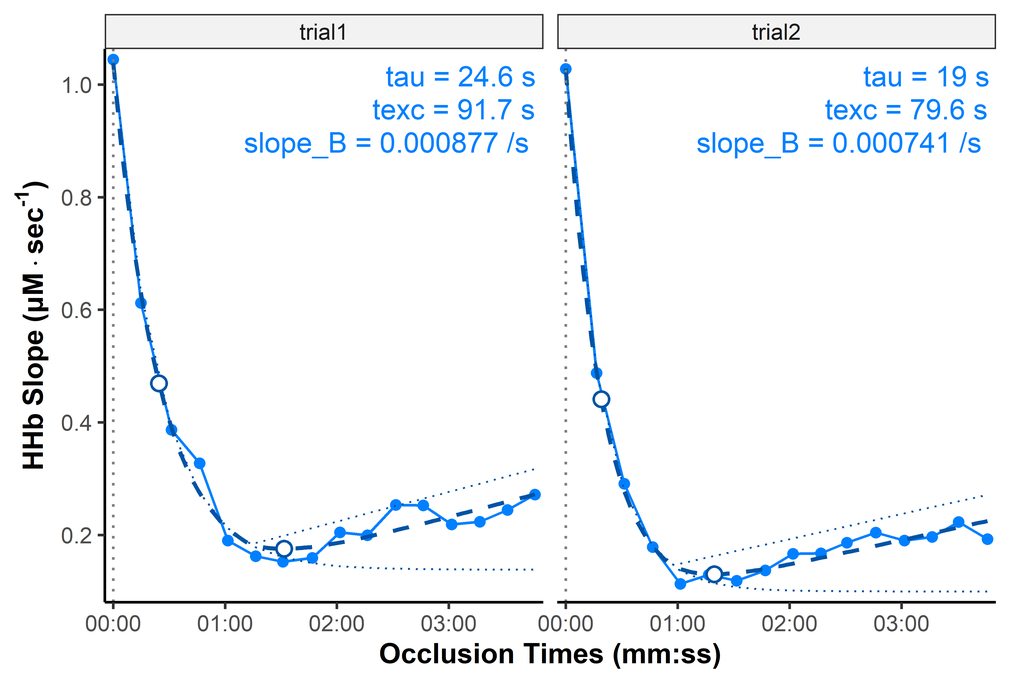

```r
plot(
    exp_drift_results,
    time_labels = TRUE,
    points      = TRUE,
    label_size  = 5,
    components  = TRUE
) +
    labs(
        x = "Occlusion Times (mm:ss)",
        y = expression(bold(HHb ~ Slope ~ '(' * μM %.% sec^'-1' * ')')),
    ) +
    theme(legend.position = "none")
```

We can evaluate the fit diagnostics for this advanced kinetics fit, however we should be cautious directly comparing the diagnostic values without first considering `n_obs` and `n_params`; which reports the number of samples (observations) and coefficients (parameters) used by each model.

```r
## bind both fit diagnostics into a single comparison table
## compare by trial
bind_rows(
    monoexponential   = monoexp_results$diagnostics,
    exponential_drift = exp_drift_results$diagnostics,
    .id = "model"
) |>
    arrange(interval) |>
    mutate(across(where(is.numeric), \(x) signif(x, 3)))
```

```
#>               model interval nirs_channels n_obs n_params    r2 adj_r2   rmse
#> 1   monoexponential   trial1     hhb_slope    16        3 0.967  0.962 0.0397
#> 2 exponential_drift   trial1     hhb_slope    16        4 0.988  0.985 0.0240
#> 3   monoexponential   trial2     hhb_slope    16        3 0.975  0.971 0.0343
#> 4 exponential_drift   trial2     hhb_slope    16        4 0.995  0.994 0.0147
#>   cv_rmse  snr   aic  aicc   bic
#> 1  0.1300 14.9 -49.8 -46.2 -46.7
#> 2  0.0783 19.2 -63.9 -57.9 -60.1
#> 3  0.1370 16.1 -54.5 -50.8 -51.4
#> 4  0.0587 23.4 -79.6 -73.6 -75.7
```

We can see that fit diagnostics are better in an absolute sense for the exponential-drift model. Because the two models are fit to identical data but differ in `n_params`, the unpenalised diagnostics (`r2`, `rmse`, `snr`) will always favour the more flexible model. For this comparison, they are not evidence of *“better fit”* on their own.

The information criteria (`aic`, `aicc`, `bic`) are unitless estimators of prediction error, and penalise extra parameters. Lower values are *“better”* (read elsewhere about the *Akaike* and *Bayesian Information Criterion*). Therefore, because all three are lower (more negative) for the exponential-drift model in both trials, this supports the advanced model as a statically *“better fit”*, explaining relatively more of the signal vs noise.

However, this suggests nothing about the *physiological rationale* for the added linear drift component, which takes precedence over any purely statistical *“goodness-of-fit”* test. That is a speculative question for another time!

# A concise processing pipeline

This article demonstrates how muscle oxidative capacity analysis can be performed using *{mnirs}* with relatively simple, reproducible data wrangling steps.

*{mnirs}* is built with a strong focus on plotting incremental processing & analysis steps along the way. In my opinion, this is an important visual validation step to perform whenever performing multi-step processing & analysis. When working with a familiar dataset, the processing & analysis pipeline can be considerably simplified compared to above:

```r
read_mnirs(
    file_path       = example_mnirs("portamon_oxcap.xlsx"),
    nirs_channels   = c(thb = 2, hhb = 3, o2hb = 4),
    event_channel   = c(event = "labels")
) |>
    correct_blood_volume(
        oxy_channel     = o2hb,
        deoxy_channel   = hhb,
        total_channel   = thb
    ) |>
    extract_intervals(
        start           = "Occlusion",
        span            = c(1, 5)
    ) |>
    analyse_kinetics(
        nirs_channels   = hhb,
        method          = "peak_slope",
        span            = 3
    ) |>
    analyse_kinetics(
        nirs_channels   = slope,
        time_channel    = peak_slope_time,
        method          = "monoexponential",
        use_TD          = FALSE,
        group_intervals = list(1:16, 17:32),
        zero_time       = TRUE
    ) |>
    print() |>
    plot()
```

Future development could wrap these steps into a dedicated convenience function with recommended default parameters, streamlining the analysis process. However, there are always trade-offs between automation and customisation: fitting nonlinear models to sparse, noisy biological data can produce unstable fit parameters or fail to converge. Manual processing steps may still be needed to accommodate these limitations.

## References

Adami, A., & Rossiter, H. B. (2018). Principles, insights, and potential pitfalls of the noninvasive determination of muscle oxidative capacity by near-infrared spectroscopy [Journal Article]. *J Appl Physiol (1985)*, *124*(1), 245–248. https://doi.org/10.1152/japplphysiol.00445.2017

Beever, A. T., Tripp, T. R., Zhang, J., & MacInnis, M. J. (2020). NIRS-derived skeletal muscle oxidative capacity is correlated with aerobic fitness and independent of sex [Journal Article]. *J Appl Physiol (1985)*, *129*(3), 558–568. https://doi.org/10.1152/japplphysiol.00017.2020

Costalat, G., Sautillet, B., Millet, G. P., Unal, C., Abaidia, A. E., Hassar, A., & Cozette, M. (2025). Steepest near-infrared spectroscopy-derived deoxygenation slopes during arterial occlusions provide more reliable assessments of muscle mitochondrial capacity [Journal Article]. *Exp Physiol*. https://doi.org/10.1113/EP093040

McCully, K. K., Stoddard, S. N., Reynolds, M. A., & Ryan, T. E. (2024). Skeletal muscle oxidative metabolism during exercise measured with near infrared spectroscopy [Journal Article]. *NDT*, *2*(4), 417–429. https://doi.org/10.3390/ndt2040025

Rasica, L., Inglis, E. C., Mazzolari, R., Iannetta, D., & Murias, J. M. (2024). Methodological considerations on near-infrared spectroscopy derived muscle oxidative capacity [Journal Article]. *European Journal of Applied Physiology*. https://doi.org/10.1007/s00421-024-05421-6

Ryan, T. E., Erickson, M. L., Brizendine, J. T., Young, H. J., & McCully, K. K. (2012). Noninvasive evaluation of skeletal muscle mitochondrial capacity with near-infrared spectroscopy: Correcting for blood volume changes [Journal Article]. *J Appl Physiol (1985)*, *113*(2), 175–183. https://doi.org/10.1152/japplphysiol.00319.2012

Ryan, T. E., Southern, W. M., Reynolds, M. A., & McCully, K. K. (2013). A cross-validation of near-infrared spectroscopy measurements of skeletal muscle oxidative capacity with phosphorus magnetic resonance spectroscopy [Journal Article]. *J Appl Physiol (1985)*, *115*(12), 1757–1766. https://doi.org/10.1152/japplphysiol.00835.2013

Tripp, T. R., McDougall, R. M., Frankish, B. P., Wiley, J. P., Lun, V., & MacInnis, M. J. (2023). Contraction intensity affects NIRS-derived skeletal muscle oxidative capacity but not its relationships to mitochondrial protein content or aerobic fitness [Journal Article]. *Journal of Applied Physiology*. https://doi.org/10.1152/japplphysiol.00342.2023